# Exploratory_Data_Analysis_1

```python
# imports
import datetime
import calendar
import pandas as pd
import matplotlib.pyplot as plt
import seaborn as sns
%matplotlib inline
```

## Reading in the data

EDA is one of the important steps in builidng a machine learning model. It helps in feature selection and dimensionality reduction. Feature selection helps in deciding the candidate features in supervised or unsupervised machine learning models.

Using both training and testing data for EDA can lead to selecting bad models because we get low cross validation error which is not natural. So only Training data is used for exploratory data analysis becuase it gives good feature selection compared to the features selection when both training and testing data are used.

```python
data = pd.read_csv('../data/train.csv')
```

```python
data.head()
```

|  | id | vendor_id | pickup_datetime | dropoff_datetime | passenger_count | pickup_longitude | pickup_latitude | dropoff_longitude | dropoff_latitude | store_and_fwd_flag | trip_duration |
| --- | --- | --- | --- | --- | --- | --- | --- | --- | --- | --- | --- |
| 0 | id2875421 | 2 | 2016-03-14 17:24:55 | 2016-03-14 17:32:30 | 1 | -73.982155 | 40.767937 | -73.964630 | 40.765602 | N | 455 |
| 1 | id2377394 | 1 | 2016-06-12 00:43:35 | 2016-06-12 00:54:38 | 1 | -73.980415 | 40.738564 | -73.999481 | 40.731152 | N | 663 |
| 2 | id3858529 | 2 | 2016-01-19 11:35:24 | 2016-01-19 12:10:48 | 1 | -73.979027 | 40.763939 | -74.005333 | 40.710087 | N | 2124 |
| 3 | id3504673 | 2 | 2016-04-06 19:32:31 | 2016-04-06 19:39:40 | 1 | -74.010040 | 40.719971 | -74.012268 | 40.706718 | N | 429 |
| 4 | id2181028 | 2 | 2016-03-26 13:30:55 | 2016-03-26 13:38:10 | 1 | -73.973053 | 40.793209 | -73.972923 | 40.782520 | N | 435 |

```python
# Checking for the null values
data.info()
```

```
<class 'pandas.core.frame.DataFrame'>
RangeIndex: 1458644 entries, 0 to 1458643
Data columns (total 11 columns):
 #   Column              Non-Null Count    Dtype
---  ------              --------------    -----
 0   id                  1458644 non-null  object
 1   vendor_id           1458644 non-null  int64
 2   pickup_datetime     1458644 non-null  object
 3   dropoff_datetime    1458644 non-null  object
 4   passenger_count     1458644 non-null  int64
 5   pickup_longitude    1458644 non-null  float64
 6   pickup_latitude     1458644 non-null  float64
 7   dropoff_longitude   1458644 non-null  float64
 8   dropoff_latitude    1458644 non-null  float64
 9   store_and_fwd_flag  1458644 non-null  object
 10  trip_duration       1458644 non-null  int64
dtypes: float64(4), int64(3), object(4)
memory usage: 122.4+ MB
```

There are no null values in any column, hence there is no need to remove the null values.

Lets us take a look at the following questions

- Let us See the trends of trips w.r.t. seasons, months, holidays
- Let us See the trends of trips during a day.
- Let us See the trends of duration trip during seasons, months and holidays.
- Let us See the trends of duration trip during a day

#### Trends of Trips w.r.t seasons, months, holidays and time of day

```python
# Matplotlib defaults
def set_default_args():
    plt.rcParams['figure.figsize'] = [6,4]
    plt.rcParams['figure.dpi'] = 72
    plt.rcParams['axes.labelsize'] = 'medium'
    plt.rcParams['axes.titlesize'] = 'large'
    plt.xticks(fontsize=10)
    plt.yticks(fontsize=10)


def enlarge_image():
    plt.rcParams['figure.figsize'] = [20,10]
    plt.rcParams['figure.dpi'] = 200
    plt.rcParams['axes.labelsize'] = 25
    plt.rcParams['axes.titlesize'] = 25
    plt.xticks(fontsize=20)
    plt.yticks(fontsize=20)
```

```python
# Taking the pickup_datetime column
pickup_time = pd.DataFrame(data.pickup_datetime.astype('datetime64[ns]'))
pickup_time['date'] = pickup_time.pickup_datetime.dt.date
pickup_time['month'] = pickup_time.pickup_datetime.dt.month
pickup_time['hour'] = pickup_time.pickup_datetime.dt.hour
pickup_time['day'] = pickup_time.pickup_datetime.dt.day
pickup_time['week'] = pickup_time.pickup_datetime.dt.dayofweek
```

```python
pickup_time.head()
```

|  | pickup_datetime | date | month | hour | day | week |
| --- | --- | --- | --- | --- | --- | --- |
| 0 | 2016-03-14 17:24:55 | 2016-03-14 | 3 | 17 | 14 | 0 |
| 1 | 2016-06-12 00:43:35 | 2016-06-12 | 6 | 0 | 12 | 6 |
| 2 | 2016-01-19 11:35:24 | 2016-01-19 | 1 | 11 | 19 | 1 |
| 3 | 2016-04-06 19:32:31 | 2016-04-06 | 4 | 19 | 6 | 2 |
| 4 | 2016-03-26 13:30:55 | 2016-03-26 | 3 | 13 | 26 | 5 |

```python
# plotting month vs number of trips
month_counts = pickup_time.month.value_counts().sort_index()
hour_counts = pickup_time.hour.value_counts().sort_index()
date_counts = pickup_time.date.value_counts()
day_counts = pickup_time.day.value_counts().sort_index()
dayofweek_counts = pickup_time.week.value_counts().sort_index()
```

```python
l_dt = date_counts.index[date_counts.shape[0]-1]
h_dt = date_counts.index[0]
print('{}-{}-{} has the least number of trips: {}, while {}-{}-{} has the highest number of trips: {}'.format(l_dt.year,l_dt.month, l_dt.day, date_counts.iloc[date_counts.shape[0]-1], h_dt.year,h_dt.month, h_dt.day, date_counts.iloc[0]))
```

```
2016-1-23 has the least number of trips: 1648, while 2016-4-9 has the highest number of trips: 9796
```

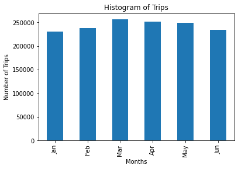

```python
set_default_args()
month_counts.plot(kind = 'bar')
plt.xlabel('Months')
plt.xticks(range(0,6),['Jan','Feb','Mar','Apr','May','Jun'])
plt.ylabel('Number of Trips')
plt.title('Histogram of Trips')

plt.show()
```

```python
print('Winter average trips {}'.format((month_counts.iloc[0] + month_counts.iloc[1])/2))
print('Spring average trips {}'.format((month_counts.iloc[2] + month_counts.iloc[3] + month_counts.iloc[4])/3))
print('Summer average trips {}'.format( month_counts.iloc[5]))
```

```
Winter average trips 234003.5
Spring average trips 252107.0
Summer average trips 234316
```

- There is gradual increase in demand for taxis from January to March and then there is steady decrease from April to June.
- Winter has the least number of averaage trips while Spring has the highest.

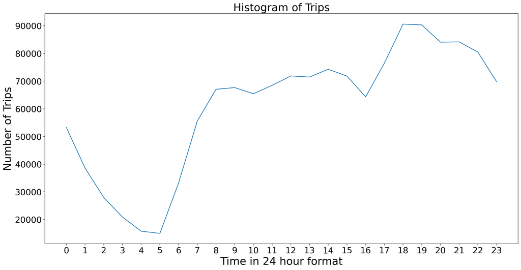

```python
# plotting time of the day vs number of trips
enlarge_image()
hour_counts.plot(kind='line')
plt.xlabel('Time in 24 hour format')
plt.ylabel('Number of Trips')
plt.xticks(range(24))
plt.title('Histogram of Trips')

plt.show()
```

```python
hour_counts1 = pickup_time.hour.value_counts()
l_dt = hour_counts1.index[hour_counts.shape[0]-1]
h_dt = hour_counts1.index[0]
print('Hour {} has the least number of trips: {}, while Hour {} has the highest number of trips: {}'.format(l_dt, hour_counts1.iloc[hour_counts1.shape[0]-1], h_dt, hour_counts1.iloc[0]))
```

```
Hour 5 has the least number of trips: 15002, while Hour 18 has the highest number of trips: 90600
```

- There is decreasing trend from midnight 12 to morning 5 A.M.
- From 5 A.M. to 8 A.M. there is more demand for taxis and huge surge in demand for taxis.
- Later from 8 A.M. to 2 P.M. there is a gradual increase in the demand.
- But there is sudden decrease from 2 P.M. to 4 P.M. for the demand
- From 4 P.M. to 6 P.M. there is a huge rise in demand and the highest number of taxi trips is at 6 P.M.
- After 6 P.M. there is a gruadual decreasing trend till 12 A.M., which continues till 5 A.M. in the morning.

```python
# plotting time of the day vs number of trips
day_counts1 = day_counts.copy(True)
day_counts1[:29] = day_counts1[:29]/5
day_counts1[30] = day_counts1[30]/2
day_counts1[31] = day_counts1[31]/3
```

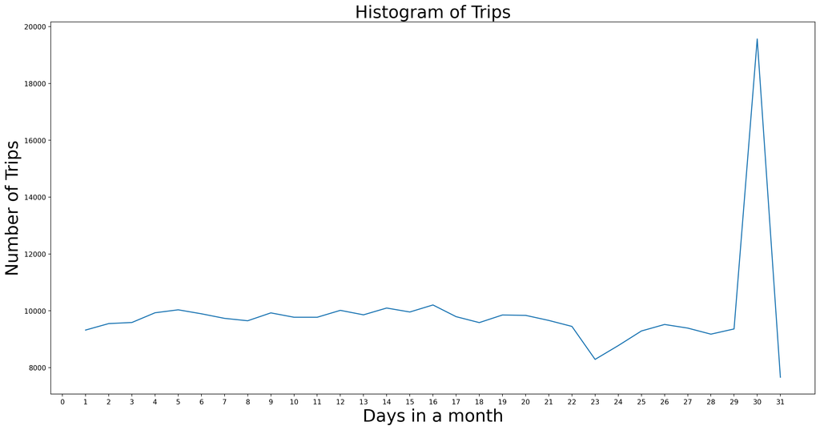

```python
day_counts1.plot(kind='line')
plt.xlabel('Days in a month')
plt.ylabel('Number of Trips')
plt.xticks(range(32))
plt.title('Histogram of Trips')

plt.show()
```

- The number of trips were increasing day by day starting from the month.
- There is light decrease on 23rd day. However there is a drastic change from 29th to 30th day, there is peak rise in number of trips. This can be an anamoly.
- Again from 30th to 31st, there is a decreasing trend.

```python
# Function to calculate daysof the week
def weekday_count(start, end):
    start_date  = datetime.datetime.strptime(start, '%d/%m/%Y')
    end_date    = datetime.datetime.strptime(end, '%d/%m/%Y')
    week        = {}
    for i in range((end_date - start_date).days):
        day       = calendar.day_name[(start_date + datetime.timedelta(days=i+1)).weekday()]
        week[day] = week[day] + 1 if day in week else 1
    return week

count_dict = weekday_count("31/12/2015","30/06/2016")
print(count_dict)
```

```
{'Friday': 26, 'Saturday': 26, 'Sunday': 26, 'Monday': 26, 'Tuesday': 26, 'Wednesday': 26, 'Thursday': 26}
```

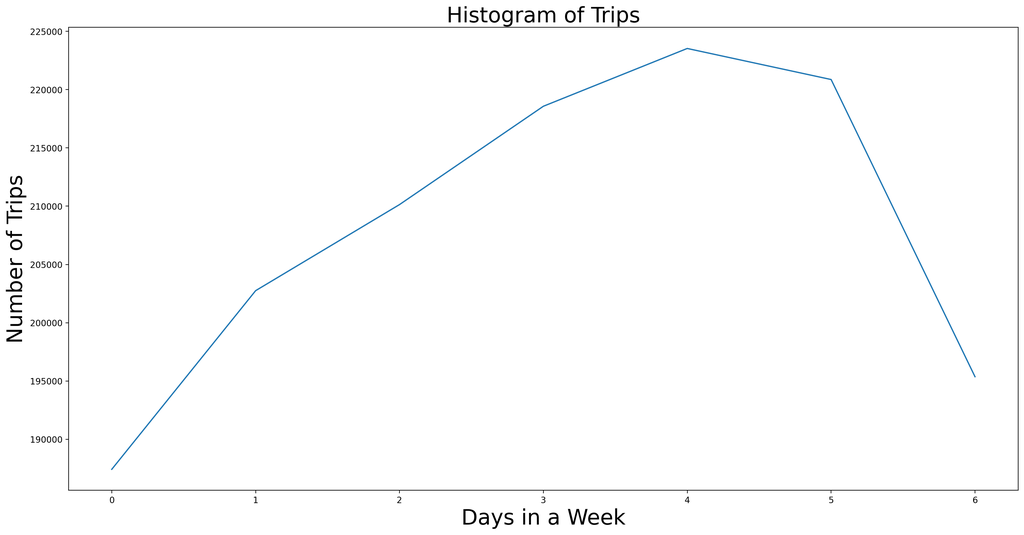

```python
# Since all the days of the week is 26 it is okay to continue with the count instead of avg
dayofweek_counts.plot(kind='line')
plt.xlabel('Days in a Week')
plt.ylabel('Number of Trips')
plt.xticks(range(7))
plt.title('Histogram of Trips')

plt.show()
```

- Friday has the most number of trips compared to any other day of the week.
- Monday has the least number of trips comapred to any other day of the week.

#### Trip Duration vs day, month, season

```python
# Adding trip duration details to pickup_time dataframe
pickup_time['duration'] = data.trip_duration
```

```python
pickup_time.head()
```

|  | pickup_datetime | date | month | hour | day | week | duration |
| --- | --- | --- | --- | --- | --- | --- | --- |
| 0 | 2016-03-14 17:24:55 | 2016-03-14 | 3 | 17 | 14 | 0 | 455 |
| 1 | 2016-06-12 00:43:35 | 2016-06-12 | 6 | 0 | 12 | 6 | 663 |
| 2 | 2016-01-19 11:35:24 | 2016-01-19 | 1 | 11 | 19 | 1 | 2124 |
| 3 | 2016-04-06 19:32:31 | 2016-04-06 | 4 | 19 | 6 | 2 | 429 |
| 4 | 2016-03-26 13:30:55 | 2016-03-26 | 3 | 13 | 26 | 5 | 435 |

```python
# Get the most busiest day and least busiest day
avg_duration_date = pickup_time.groupby(['date'])['duration'].mean()
avg_duration_month = pickup_time.groupby(['month'])['duration'].mean()
avg_duration_hour = pickup_time.groupby(['hour'])['duration'].mean()
avg_duration_day = pickup_time.groupby(['day'])['duration'].mean()
avg_duration_dow  =pickup_time.groupby(['week'])['duration'].mean()
```

```python
print('The Most busiest day is -',avg_duration_date[avg_duration_date == avg_duration_date.max()],'\n')
print('The least busiest day is -',avg_duration_date[avg_duration_date == avg_duration_date.min()])
```

```
The Most busiest day is - date
2016-02-13    1482.958105
Name: duration, dtype: float64

The least busiest day is - date
2016-01-18    715.627764
Name: duration, dtype: float64
```

```python
print('The Most busiest hour is -',avg_duration_hour[avg_duration_hour == avg_duration_hour.max()],'\n')
print('The least busiest hour is -',avg_duration_hour[avg_duration_hour == avg_duration_hour.min()])
```

```
The Most busiest hour is - hour
15    1118.832533
Name: duration, dtype: float64

The least busiest hour is - hour
6    797.434943
Name: duration, dtype: float64
```

```python
print('The Most busiest month is -',avg_duration_month[avg_duration_month == avg_duration_month.max()],'\n')
print('The least busiest month is -',avg_duration_month[avg_duration_month == avg_duration_month.min()])
```

```
The Most busiest month is - month
6    1013.367226
Name: duration, dtype: float64

The least busiest month is - month
2    920.830453
Name: duration, dtype: float64
```

```python
print('The Most busiest day of the month is -',avg_duration_day[avg_duration_day == avg_duration_day.max()],'\n')
print('The least busiest day of the month is -',avg_duration_day[avg_duration_day == avg_duration_day.min()])
```

```
The Most busiest day of the month is - day
13    1067.434301
Name: duration, dtype: float64

The least busiest day of the month is - day
7    900.626102
Name: duration, dtype: float64
```

```python
print('The Most busiest day of the week is -',avg_duration_dow[avg_duration_dow == avg_duration_dow.max()],'\n')
print('The least busiest day of the week is -',avg_duration_dow[avg_duration_dow == avg_duration_dow.min()])
```

```
The Most busiest day of the week is - week
3    1006.528654
Name: duration, dtype: float64

The least busiest day of the week is - week
0    897.947839
Name: duration, dtype: float64
```

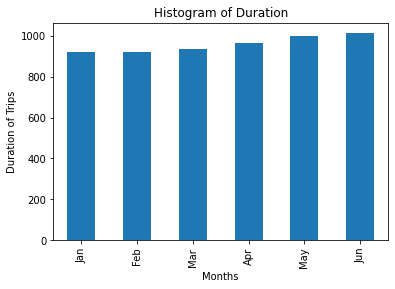

```python
# Plotting duration of trip vs months
set_default_args()
avg_duration_month.plot(kind = 'bar')
plt.xlabel('Months')
plt.xticks(range(0,6),['Jan','Feb','Mar','Apr','May','Jun'])
plt.ylabel('Duration of Trips')
plt.title('Histogram of Duration')

plt.show()
```

- As obsereved there is an increasing trend in the duration of trips from January to June.
- This might be one of the reasons for less number of trips in Summer, as the duration of trips increases, the supply decreases adn eventually number of trips will decrease.

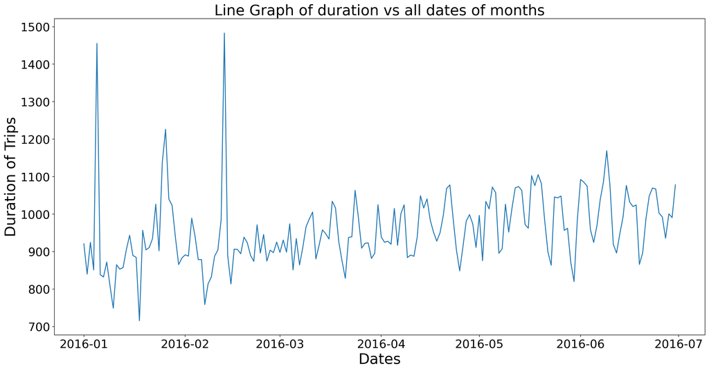

```python
# plotting duration of trips vs all dates of months
enlarge_image()
avg_duration_date.plot(kind='line')
plt.xlabel('Dates')
plt.ylabel('Duration of Trips')
plt.title('Line Graph of duration vs all dates of months')
plt.show()
```

- The above graph indicates the duration of trips from January to June.
- It can be inferred from the plot that during the months of January and February the duration of trips was reaching its maximum value.

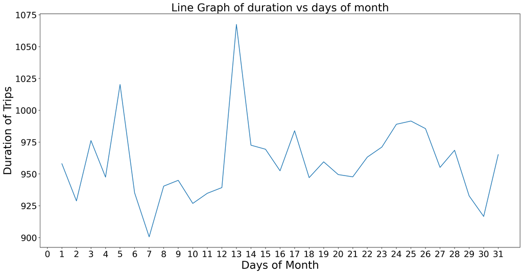

```python
# plotting duration of trips vs day of month
enlarge_image()
avg_duration_day.plot(kind='line')
plt.xlabel('Days of Month')
plt.ylabel('Duration of Trips')
plt.xticks(range(32))
plt.title('Line Graph of duration vs days of month')
plt.show()
```

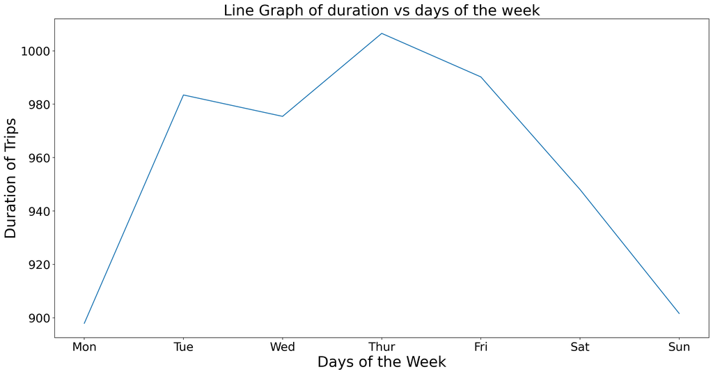

```python
# plotting duration of trips vs day of the week
enlarge_image()
avg_duration_dow.plot(kind='line')
plt.xlabel('Days of the Week')
plt.ylabel('Duration of Trips')
plt.xticks(range(7),['Mon','Tue','Wed','Thur','Fri','Sat','Sun'])
plt.title('Line Graph of duration vs days of the week')
plt.show()
```

- The average duration of trips is highest on Thursday.
- The average duration of trips is least on Monday.

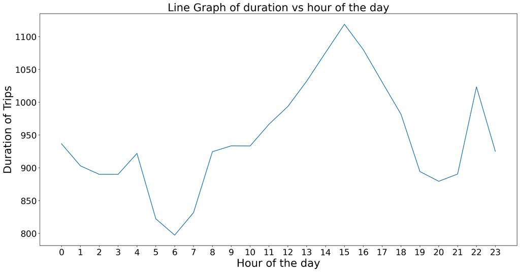

```python
# plotting duration of trips vs houe of the day
enlarge_image()
avg_duration_hour.plot(kind='line')
plt.xlabel('Hour of the day')
plt.ylabel('Duration of Trips')
plt.xticks(range(24))
plt.title('Line Graph of duration vs hour of the day')
plt.show()
```

After completing the EDA over the temporal aspect and seeing through the trends of trip duration over months, day of the month, day of the week and hour of the day, we can select these four features as the candidate_feature for building the model.

Hence, the correlations between the candidate features must be checked and if they are correlated then one of the correlated features must be eliminated in the model building process

#### Finding the correlation between the candidate features

Candidate features are as follows:

- month: Month of the year
- hour: Hour of the day
- day: day of the month
- week: day of the week

```python
pickup_time.head()
```

|  | pickup_datetime | date | month | hour | day | week | duration |
| --- | --- | --- | --- | --- | --- | --- | --- |
| 0 | 2016-03-14 17:24:55 | 2016-03-14 | 3 | 17 | 14 | 0 | 455 |
| 1 | 2016-06-12 00:43:35 | 2016-06-12 | 6 | 0 | 12 | 6 | 663 |
| 2 | 2016-01-19 11:35:24 | 2016-01-19 | 1 | 11 | 19 | 1 | 2124 |
| 3 | 2016-04-06 19:32:31 | 2016-04-06 | 4 | 19 | 6 | 2 | 429 |
| 4 | 2016-03-26 13:30:55 | 2016-03-26 | 3 | 13 | 26 | 5 | 435 |

```python
# Calculating the corr for the selected columns
df = pickup_time[['month','hour','day','week']]
corr = df.corr()
```

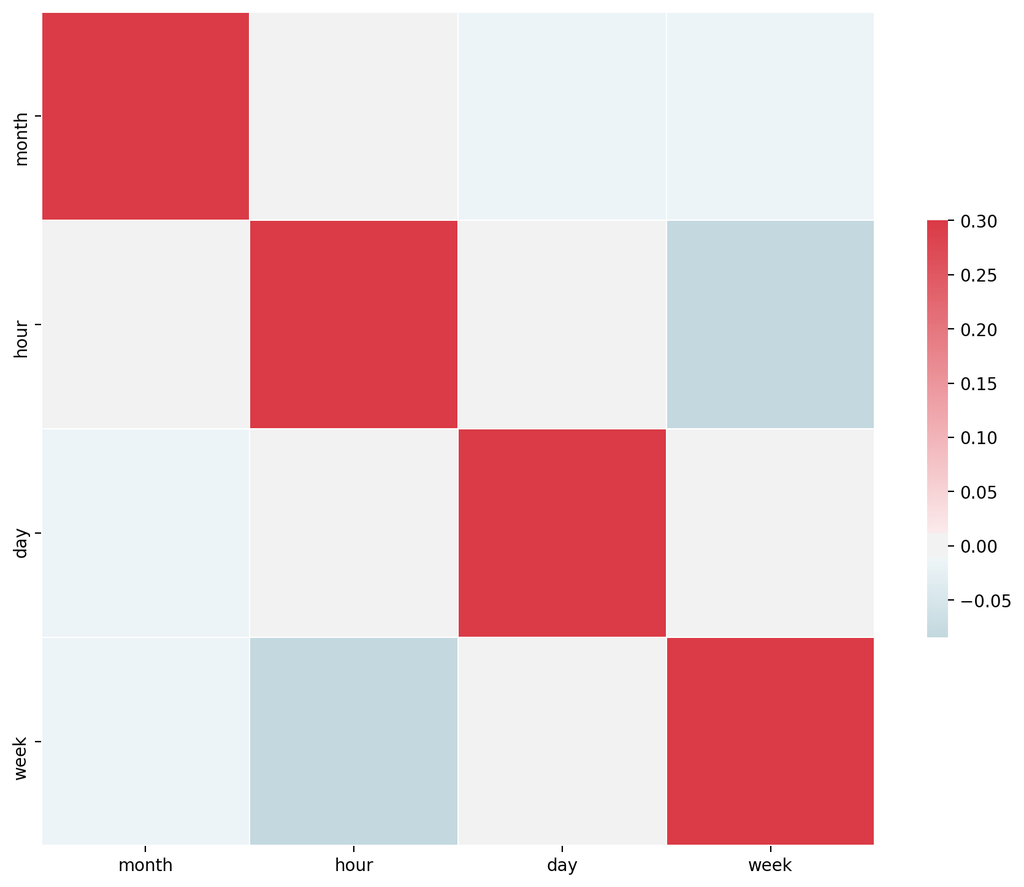

```python
# Plotting the correlation on a heat map
f, ax = plt.subplots(figsize=(11, 9))

# Generate a custom diverging colormap
cmap = sns.diverging_palette(220, 10, as_cmap=True)

# Draw the heatmap with the mask and correct aspect ratio
sns.heatmap(corr, cmap=cmap, vmax=.3, center=0,
            square=True, linewidths=.5, cbar_kws={"shrink": .5})
```

- There is no strong correlation between any of the candidate features, hence all these candidate features are used while building a model